# Joint conf-call report #3

## 1e-4 alpha 10k samples 100k time GD

I tried test pushing alpha (learning rate) up to the limit, e.g. $\alpha = \tilde{\alpha} - \epsilon$ such that:

- with $\alpha$ as learning rate the computation converges;
- with $\tilde{\alpha}$ as learning rate the computation diverges;
- $\epsilon$ is a small real value.

`alpha = 1e-4 # e.g. 10^(-4)`.

### 1e-4 alpha 10k samples 100k time GD - iter/time

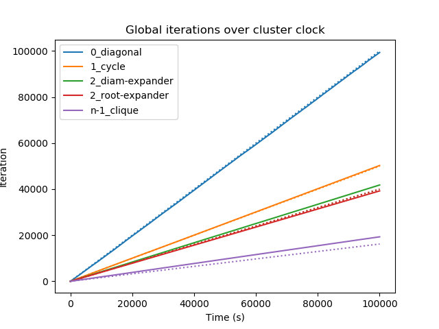

### 1e-4 alpha 10k samples 100k time GD - mse/iter

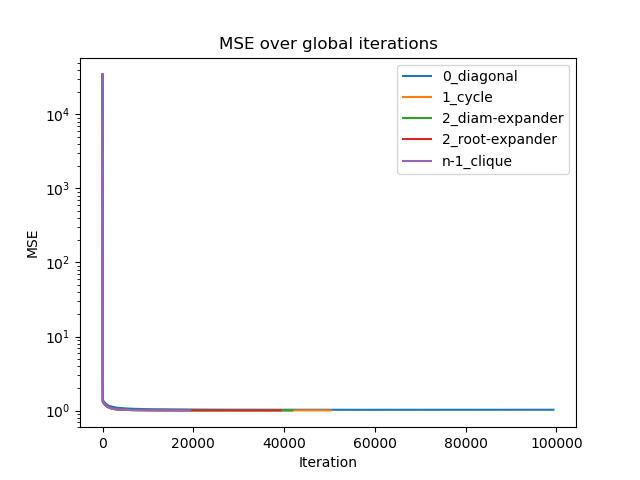

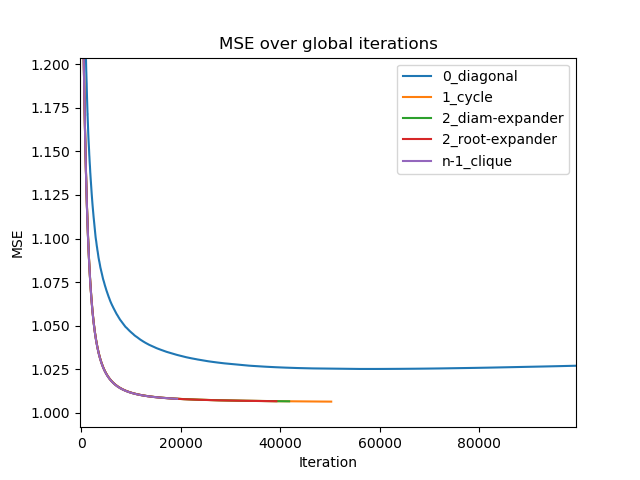

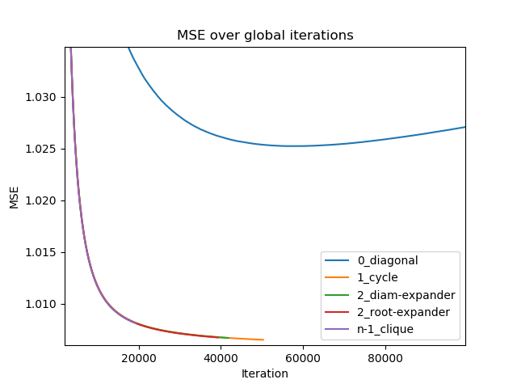

### 1e-4 alpha 10k samples 100k time GD - rmse/iter

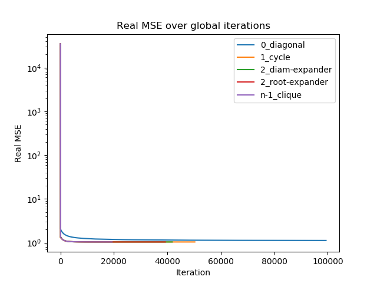

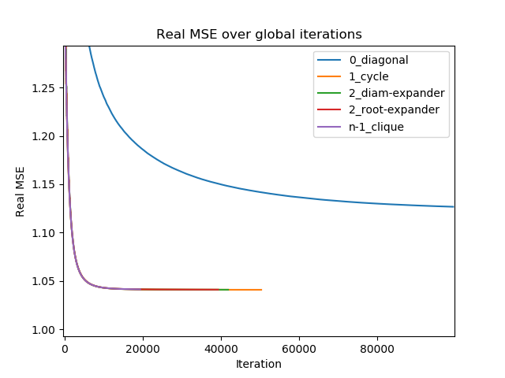

### 1e-4 alpha 10k samples 100k time GD - mse/time

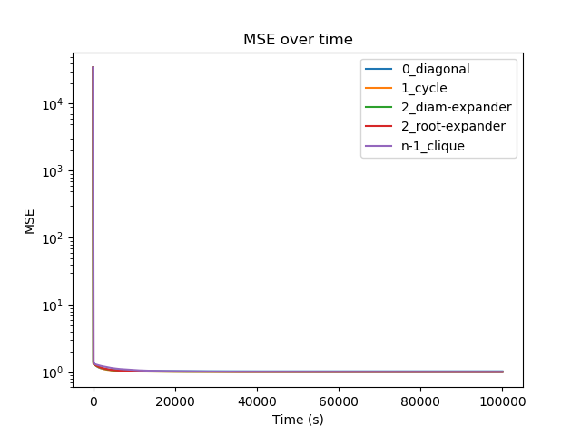

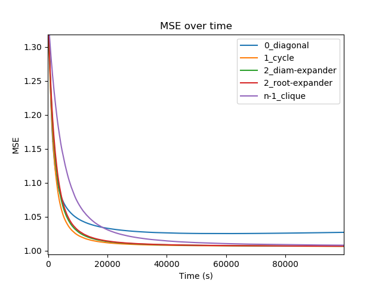

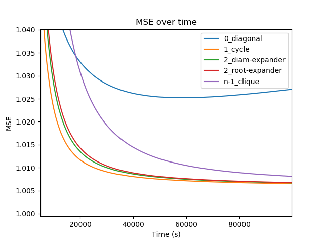

### 1e-4 alpha 10k samples 100k time GD - rmse/time

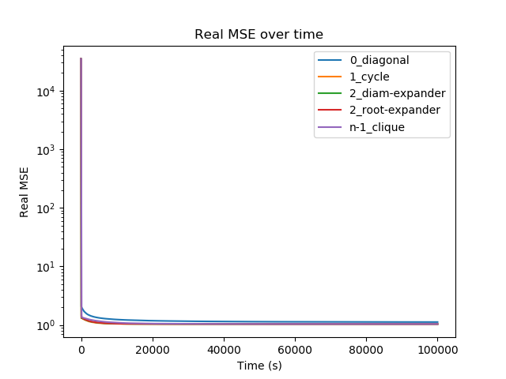

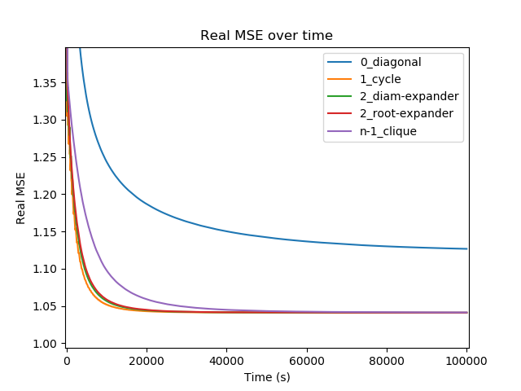

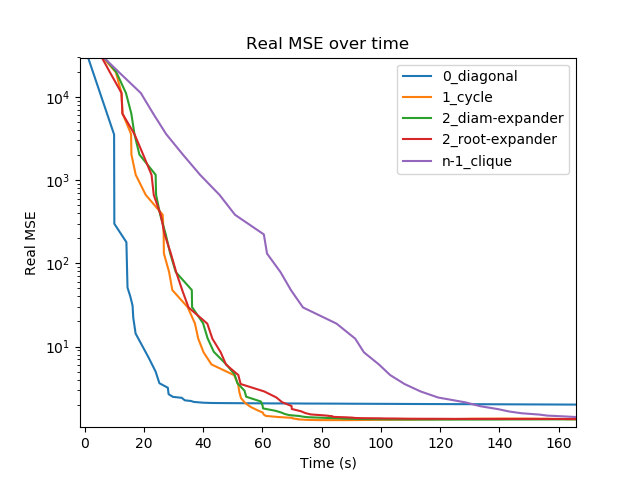

*The same test with different seeds shew almost the same results.*

I obtained such results only on May the 17th at 11:30. I will explore deeply how the learning rate affects the convergence of topologies in the next report. I am aiming to get rid quickly of diagonal topology from my tests.

## 1e-4 alpha ALT metrics 10k samples 10k time GD

The same test but with ALT metrics, e.g. error is computing averaging local errors.

`max_time` is set to $10k$ instead of $100k$.

### 1e-4 alpha ALT metrics 10k samples 10k time GD - iter/time

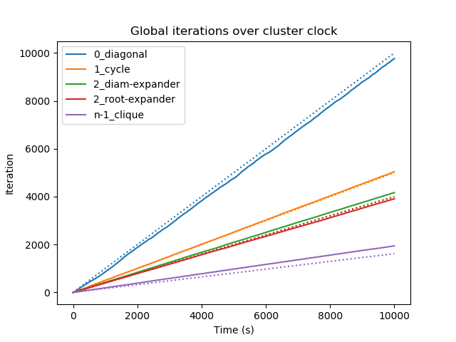

### 1e-4 alpha ALT metrics 10k samples 10k time GD - mse/iter

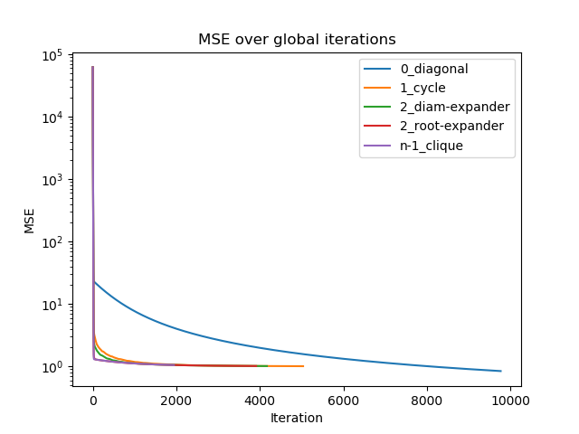

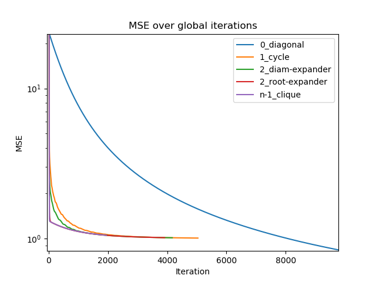

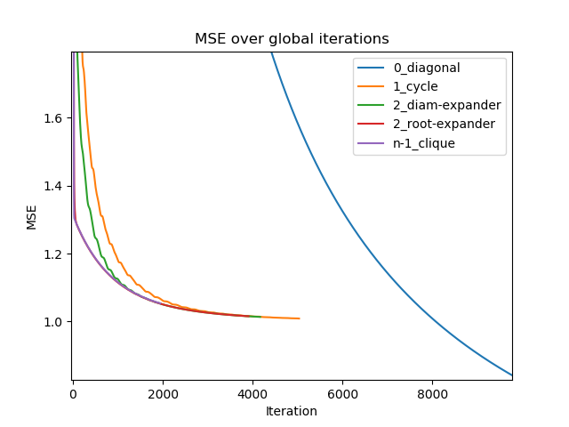

### 1e-4 alpha ALT metrics 10k samples 10k time GD - rmse/iter

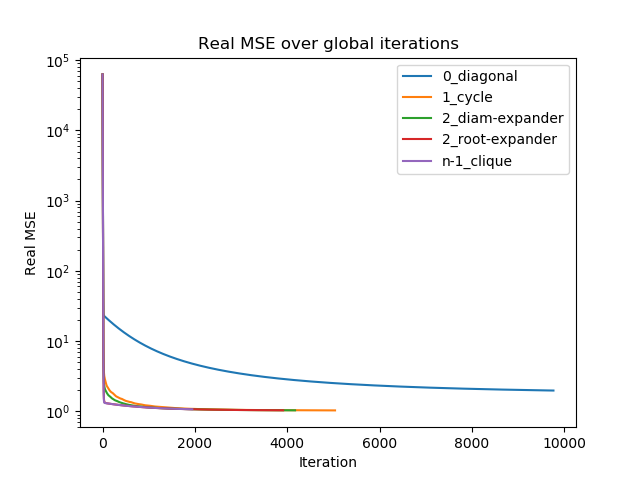

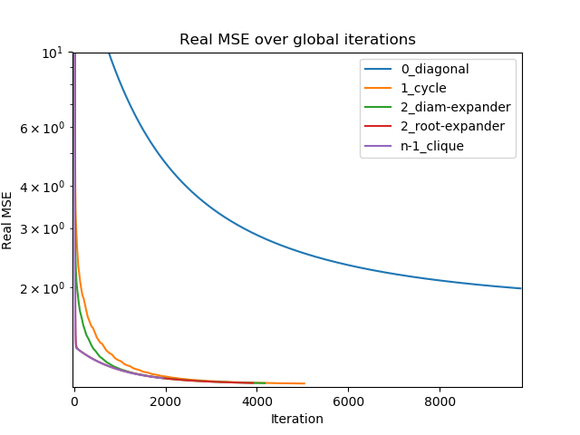

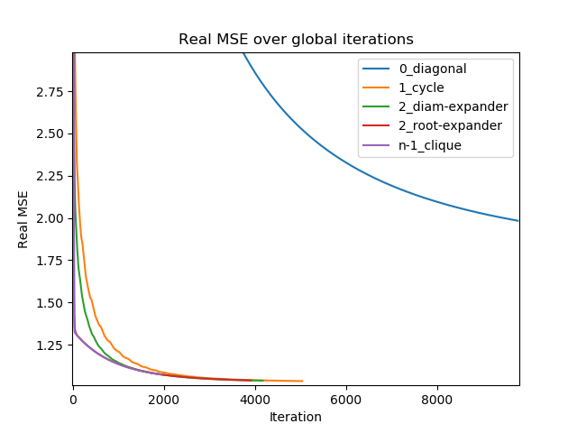

### 1e-4 alpha ALT metrics 10k samples 10k time GD - mse/time

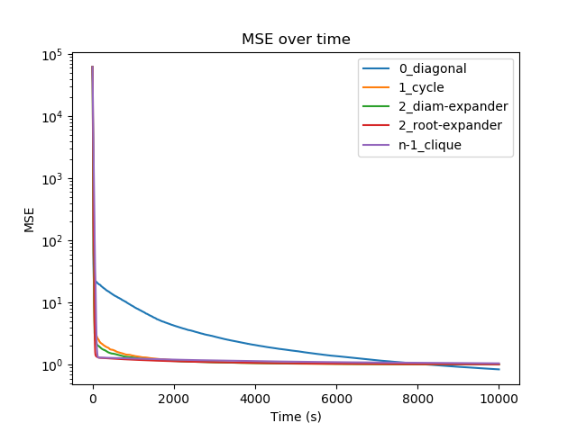

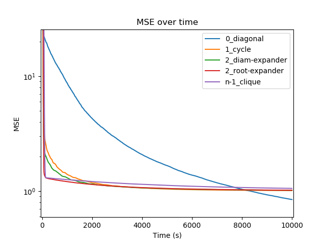

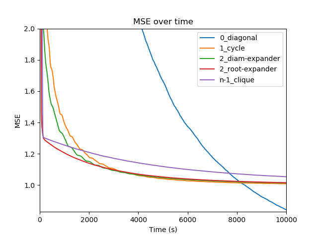

### 1e-4 alpha ALT metrics 10k samples 10k time GD - rmse/time

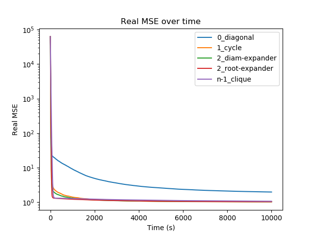

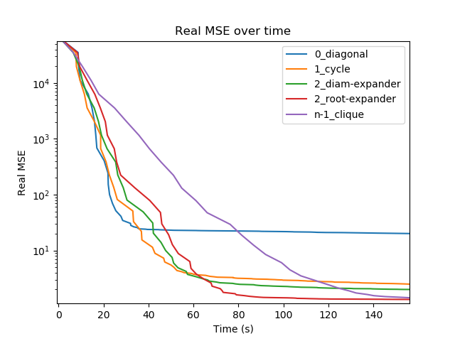

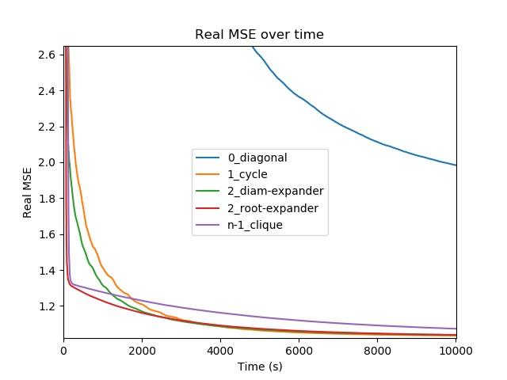